# Machine learning - Lab 2.2

# **Forest Cover Type Dataset**

**@author : Maelwenn LABIDURIE & Albane COIFFE**  
**@email : maelwenn.labidurie@efrei.net & albane.coiffe@efrei.net**  
11/09/2024

## Step 1: Setup

Imports needed for this lab

```python
from ydata_profiling import ProfileReport
import matplotlib.pyplot as plt
import seaborn as sns
import numpy as np
import pandas as pd
```

```python
from sklearn.model_selection import train_test_split
from sklearn.preprocessing import StandardScaler
from sklearn.linear_model import LogisticRegression
from sklearn.multiclass import OneVsRestClassifier
from sklearn.preprocessing import StandardScaler
from sklearn.pipeline import make_pipeline
from sklearn.metrics import confusion_matrix, classification_report
from sklearn.neighbors import KNeighborsClassifier
```

Load the dataset

```python
column_names = [
    'Elevation', 'Aspect', 'Slope', 'Horizontal_Distance_To_Hydrology',
    'Vertical_Distance_To_Hydrology', 'Horizontal_Distance_To_Roadways',
    'Hillshade_9am', 'Hillshade_Noon', 'Hillshade_3pm',
    'Horizontal_Distance_To_Fire_Points', 'Wilderness_Area1', 'Wilderness_Area2',
    'Wilderness_Area3', 'Wilderness_Area4', 'Soil_Type1', 'Soil_Type2',
    'Soil_Type3', 'Soil_Type4', 'Soil_Type5', 'Soil_Type6', 'Soil_Type7',
    'Soil_Type8', 'Soil_Type9', 'Soil_Type10', 'Soil_Type11', 'Soil_Type12',
    'Soil_Type13', 'Soil_Type14', 'Soil_Type15', 'Soil_Type16', 'Soil_Type17',
    'Soil_Type18', 'Soil_Type19', 'Soil_Type20', 'Soil_Type21', 'Soil_Type22',
    'Soil_Type23', 'Soil_Type24', 'Soil_Type25', 'Soil_Type26', 'Soil_Type27',
    'Soil_Type28', 'Soil_Type29', 'Soil_Type30', 'Soil_Type31', 'Soil_Type32',
    'Soil_Type33', 'Soil_Type34', 'Soil_Type35', 'Soil_Type36', 'Soil_Type37',
    'Soil_Type38', 'Soil_Type39', 'Soil_Type40', 'Cover_Type'
]
df = pd.read_csv('covtype.data', names=column_names, header=None)
```

Display the first few rows of the dataset

```python
df.head()
```

|  | Elevation | Aspect | Slope | Horizontal_Distance_To_Hydrology | Vertical_Distance_To_Hydrology | Horizontal_Distance_To_Roadways | Hillshade_9am | Hillshade_Noon | Hillshade_3pm | Horizontal_Distance_To_Fire_Points | ... | Soil_Type32 | Soil_Type33 | Soil_Type34 | Soil_Type35 | Soil_Type36 | Soil_Type37 | Soil_Type38 | Soil_Type39 | Soil_Type40 | Cover_Type |
| --- | --- | --- | --- | --- | --- | --- | --- | --- | --- | --- | --- | --- | --- | --- | --- | --- | --- | --- | --- | --- | --- |
| 0 | 2596 | 51 | 3 | 258 | 0 | 510 | 221 | 232 | 148 | 6279 | ... | 0 | 0 | 0 | 0 | 0 | 0 | 0 | 0 | 0 | 5 |
| 1 | 2590 | 56 | 2 | 212 | -6 | 390 | 220 | 235 | 151 | 6225 | ... | 0 | 0 | 0 | 0 | 0 | 0 | 0 | 0 | 0 | 5 |
| 2 | 2804 | 139 | 9 | 268 | 65 | 3180 | 234 | 238 | 135 | 6121 | ... | 0 | 0 | 0 | 0 | 0 | 0 | 0 | 0 | 0 | 2 |
| 3 | 2785 | 155 | 18 | 242 | 118 | 3090 | 238 | 238 | 122 | 6211 | ... | 0 | 0 | 0 | 0 | 0 | 0 | 0 | 0 | 0 | 2 |
| 4 | 2595 | 45 | 2 | 153 | -1 | 391 | 220 | 234 | 150 | 6172 | ... | 0 | 0 | 0 | 0 | 0 | 0 | 0 | 0 | 0 | 5 |

5 rows × 55 columns

## Step 2: Dataset Profiling using ydata_profiling

Generate the profiling report

```python
profile = ProfileReport(df, title='Forest Cover Type Data Report')
profile.to_file('forest_cover_report.html')
```

We can see that the distribution of the target class (`'Cover_Type'`) is highly imbalanced. The proportions of each class are as follows:

- **Class 2**: 48.8%
- **Class 1**: 36.5%
- **Class 3**: 6.2%
- **Class 7**: 3.5%
- **Class 6**: 3.0%
- **Class 5**: 1.6%
- **Class 4**: 0.5%

This indicates that some classes are significantly underrepresented compared to others, which could impact the performance of the model.

We observe that there are no missing values in the dataset. However, for the categorical features, 0 represents absence and 1 represents presence.

Notably, most of the soil types are absent (0) in almost every sample. Therefore, we can eliminate all soil type columns except for Soil_Type23 (present in 9.9% of samples) and Soil_Type29 (present in 19.8% of samples).  
Additionally, we can remove the Wilderness_Area2 column. We will keep Wilderness_Area4 because of it's correlations with the target value.

Regarding outliers, we have identified the following thresholds for certain features:

- **Slope**: Values above 40
- **Horizontal_Distance_To_Hydrology**: Values above 1000
- **Vertical_Distance_To_Hydrology**: Values above 300 and values below -100
- **Hillshade_9am**: Values below 100
- **Hillshade_Noon**: Values below 150

These thresholds help in identifying potential outliers that might need further investigation or removal.

One key takeaway from the profile report is that the target class does not have a high correlation with most of the other features. However, there are two notable exceptions:

- **Elevation**: -49.6%
- **Wilderness_Area4**: 72.9%

```python
outliers_conditions = {
    'Slope': df['Slope'] > 40,
    'Horizontal_Distance_To_Hydrology': df['Horizontal_Distance_To_Hydrology'] > 1000,
    'Vertical_Distance_To_Hydrology': (df['Vertical_Distance_To_Hydrology'] > 300) |
                                     (df['Vertical_Distance_To_Hydrology'] < -100),
    'Hillshade_9am': df['Hillshade_9am'] < 100,
    'Hillshade_Noon': df['Hillshade_Noon'] < 150
}

outlier_conditions_combined = pd.concat(outliers_conditions.values(), axis=1).any(axis=1)

df_cleaned = df[~outlier_conditions_combined]
```

```python
columns_to_drop = [
    'Soil_Type1', 'Soil_Type2', 'Soil_Type3', 'Soil_Type4', 'Soil_Type5', 'Soil_Type6',
    'Soil_Type7', 'Soil_Type8', 'Soil_Type9', 'Soil_Type10', 'Soil_Type11', 'Soil_Type12',
    'Soil_Type13', 'Soil_Type14', 'Soil_Type15', 'Soil_Type16', 'Soil_Type17',
    'Soil_Type18', 'Soil_Type19', 'Soil_Type20', 'Soil_Type21', 'Soil_Type22',
    'Soil_Type24', 'Soil_Type25', 'Soil_Type26', 'Soil_Type27', 'Soil_Type28',
    'Soil_Type30', 'Soil_Type31', 'Soil_Type32', 'Soil_Type33', 'Soil_Type34',
    'Soil_Type35', 'Soil_Type36', 'Soil_Type37', 'Soil_Type38', 'Soil_Type39',
    'Soil_Type40', 'Wilderness_Area2'
]

df_cleaned = df_cleaned.drop(columns=columns_to_drop, errors='ignore')
```

```python
df_cleaned.info()
```

```
<class 'pandas.core.frame.DataFrame'>
Index: 571287 entries, 0 to 581011
Data columns (total 16 columns):
 #   Column                              Non-Null Count   Dtype
---  ------                              --------------   -----
 0   Elevation                           571287 non-null  int64
 1   Aspect                              571287 non-null  int64
 2   Slope                               571287 non-null  int64
 3   Horizontal_Distance_To_Hydrology    571287 non-null  int64
 4   Vertical_Distance_To_Hydrology      571287 non-null  int64
 5   Horizontal_Distance_To_Roadways     571287 non-null  int64
 6   Hillshade_9am                       571287 non-null  int64
 7   Hillshade_Noon                      571287 non-null  int64
 8   Hillshade_3pm                       571287 non-null  int64
 9   Horizontal_Distance_To_Fire_Points  571287 non-null  int64
 10  Wilderness_Area1                    571287 non-null  int64
 11  Wilderness_Area3                    571287 non-null  int64
 12  Wilderness_Area4                    571287 non-null  int64
 13  Soil_Type23                         571287 non-null  int64
 14  Soil_Type29                         571287 non-null  int64
 15  Cover_Type                          571287 non-null  int64
dtypes: int64(16)
memory usage: 74.1 MB
```

```python
profile = ProfileReport(df_cleaned, title='Forest Cover Type Data Report')
profile.to_file('forest_cover_clean_report.html')
```

## Step 3: Data Preprocessing

**Feature Engineering**

```python
X = df_cleaned.drop(columns='Cover_Type')
y = df_cleaned['Cover_Type']
```

**Split the Data**

```python
X_train, X_test, y_train, y_test = train_test_split(X, y, test_size=0.2, random_state=42)
```

**Standardize or normalize the Data**

```python
scaler = StandardScaler()

X_train_scaled = scaler.fit_transform(X_train)
X_test_scaled = scaler.transform(X_test)
```

## Step 4: Model Training and Evaluation

### One-vs-All Logistic Regression

**Fit Logistic Regression**

```python
logistic_regression = LogisticRegression(solver='liblinear');

temp = OneVsRestClassifier(logistic_regression);

model = make_pipeline(StandardScaler(), temp);
model.fit(X_train, y_train);
```

**Make Predictions**

```python
y_pred = model.predict(X_test)
```

**Evaluate Logistic Regression**

```python
cm = confusion_matrix(y_test, y_pred)

report = classification_report(y_test, y_pred)
print(report)
```

```
              precision    recall  f1-score   support

           1       0.68      0.69      0.69     42186
           2       0.70      0.80      0.75     55563
           3       0.58      0.54      0.56      6866
           4       0.81      0.03      0.06       516
           5       0.00      0.00      0.00      1906
           6       0.38      0.07      0.11      3374
           7       0.91      0.08      0.14      3847

    accuracy                           0.68    114258
   macro avg       0.58      0.32      0.33    114258
weighted avg       0.67      0.68      0.66    114258
```

**Visualize the Confusion Matrix**

[figure not shown]

```python
%matplotlib inline

plt.figure(figsize=(12, 10))
sns.heatmap(cm, annot=True, cmap='BrBG', fmt='.2f', vmin=-1, vmax=1, center=0)
plt.xlabel('True values')
plt.ylabel('Predict values')
plt.title('Confusion Matrix')
plt.show()
```

### k-Nearest Neighbors (k-NN)

**Fit k-NN Model**

```python
knn = KNeighborsClassifier(n_neighbors=5);
knn.fit(X_train, y_train);
```

**Make Predictions**

```python
y_pred_knn = model.predict(X_test)
```

```python
cm_knn = confusion_matrix(y_test, y_pred_knn)

report_knn = classification_report(y_test, y_pred_knn)
print(report)
```

```
              precision    recall  f1-score   support

           1       0.68      0.69      0.69     42186
           2       0.70      0.80      0.75     55563
           3       0.58      0.54      0.56      6866
           4       0.81      0.03      0.06       516
           5       0.00      0.00      0.00      1906
           6       0.38      0.07      0.11      3374
           7       0.91      0.08      0.14      3847

    accuracy                           0.68    114258
   macro avg       0.58      0.32      0.33    114258
weighted avg       0.67      0.68      0.66    114258
```

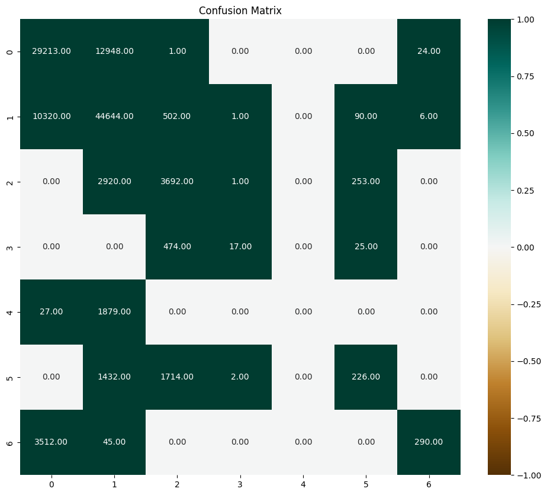

```python
%matplotlib inline

plt.figure(figsize=(12, 10))
sns.heatmap(cm_knn, annot=True, cmap='BrBG', fmt='.2f', vmin=-1, vmax=1, center=0)
plt.title('Confusion Matrix')
plt.show()
```

## Step 5: Analysis and Discussion

Comparison of Logistic Regression vs k-NN